# 산업공학특론I_중간고사

이승환 (2024122752)

4/10/2024

### [중간고사 개요]

#### 1. 중간고사 답안 작성 및 제출 요령

- 모든 답안 도출 과정은 R 코드로 작성되어야 하며, 코드에는 분석 과정을 식별할 수 있도록 주석(#)으로 설명이 작성되어야 한다. (R 코드 없이 답만 적는 경우 오답 처리)
- 수강생 간 코드를 공유하거나 동일하게 작성하는 행위를 금지한다. (적발 시 진실의 방 소환 및 모두 0점으로 성적 반영)
- 특정한 문제에 대한 답안은 해당 문항에 대한 코드에 작성되어야 한다. (1번 문항에 대한 답을 2번 문항에 적는 경우 오답 처리)
- 답안은 Rmd 확장자로 보고서 제작이 가능하도록 제출하는 것을 원칙으로 하나, Markdown 실행이 어려운 경우 R 스크립트로 작성하되 채점이 가능하도록 문항 별로 스크립트를 작성하여야 한다.
- 중간고사 답안은 4월 10일 23시 59분까지 온라인 강의실 내 과제 및 평가 - 중간고사 탭에 제출하여야 하며, 4월 11일 자정 이후에는 제출이 불가하다. (이후 다른 경로를 통하여 제출 시 총점의 50%로 성적 반영)

#### 2. 데이터 설명

어느 의류 생산 공정에서는 재봉 (sewing), 마감 (finishing)으로 부서를 구성하여 공정을 운영하고 있으며, 공정의 생산성을 개선하기 위해 일별 공정 작업 관련 데이터를 수집하여 생산성에 영향을 미치는 요인을 분석하고자 한다. 데이터 분석에 활용하는 변수의 정보는 다음과 같다.

- date: 집계 날짜
- quarter: 한 달을 나눈 분기 (주)
- department: 부서
- day: 요일
- team: 부서별 투입 인원 수
- targeted_productivity: 당초에 목표한 생산성 점수
- over_time: 초과근무 (분)
- incentive: 성과급
- actual_productivity: 실제 생산성 점수

상기에 기술된 작성요령과 데이터를 기반으로 주어진 문제에 대한 분석 과정과 그에 따른 답안을 기술하시오.

### [중간고사 문항]

#### 1. 주어진 데이터에서 데이터 탐색 (EDA) 및 전처리를 수행하고, 결과를 시각화하시오. (10점)

- 활용하지 않는 변수 (date, smv, wip, idle_time, idle_men, no_of_style_change, no_of_workers)는 삭제할 것
- 시각화 시 범주형 변수는 막대그래프로, 연속형 변수는 히스토그램으로 표현할 것

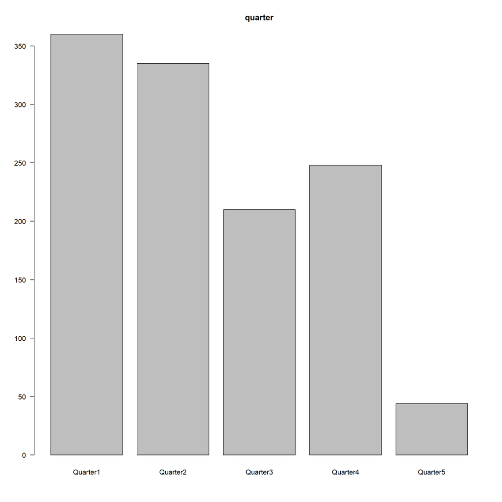

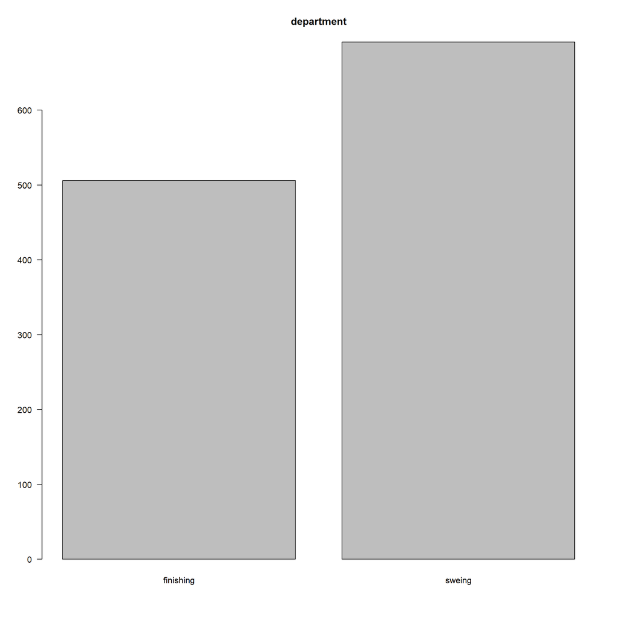

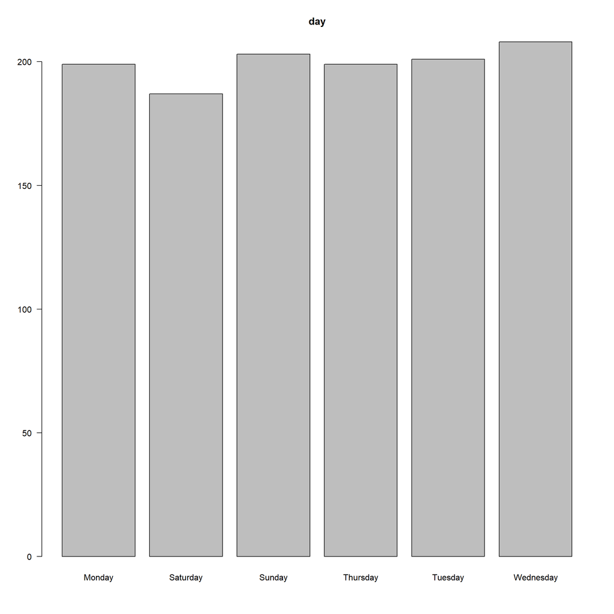

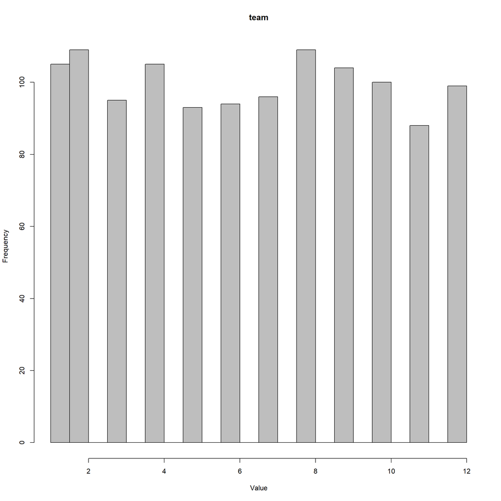

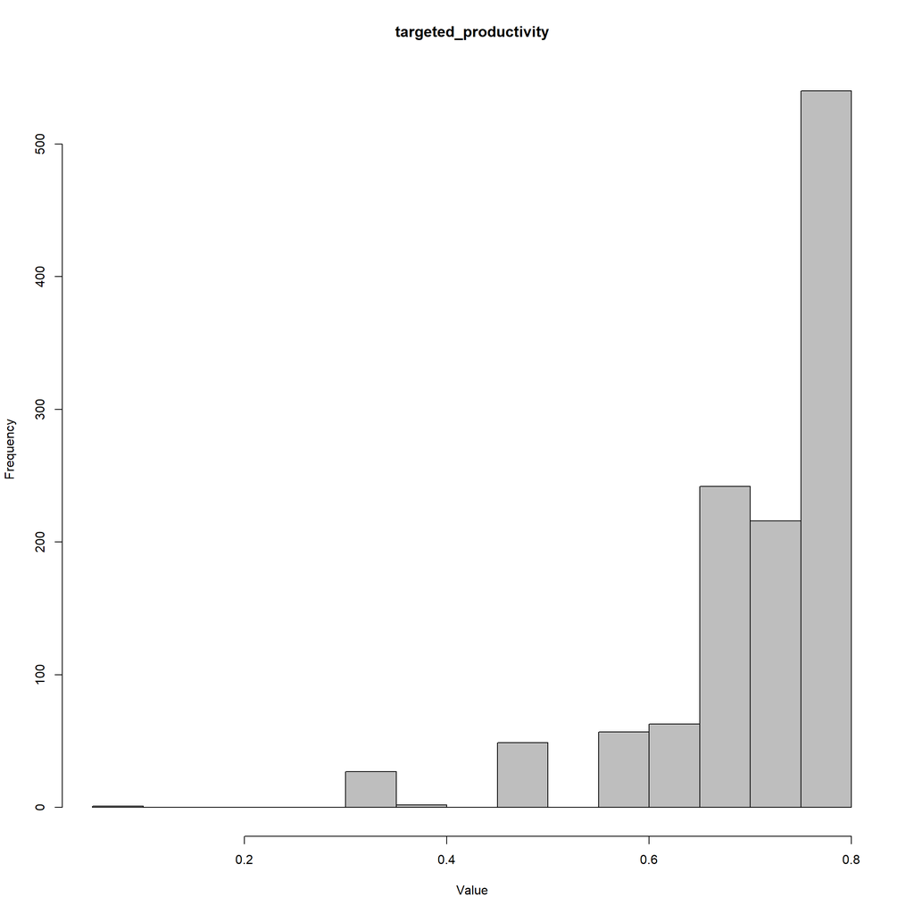

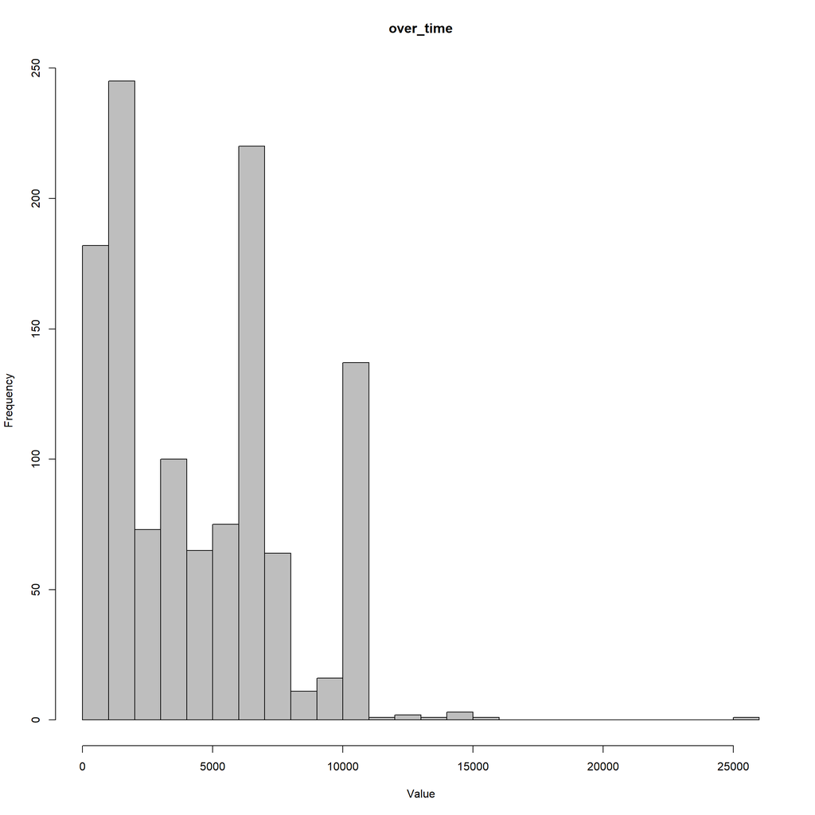

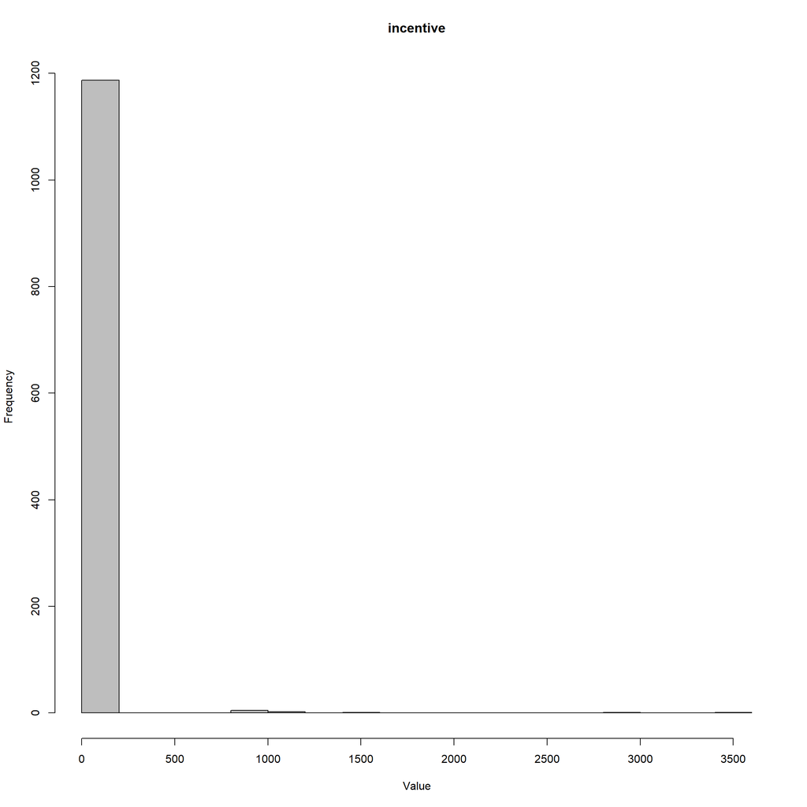

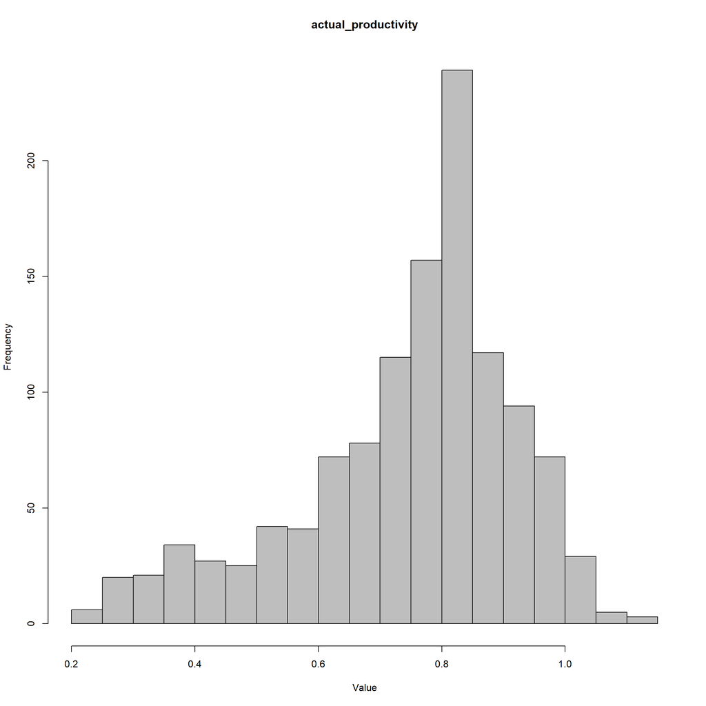

```r
# 데이터 탐색 및 전처리 수행

# 데이터 로드
dat <- read.csv('산업공학특론I_중간고사 데이터.csv')

# 활용하지 않는 변수 삭제 및 변수내 값 정리
dat <- subset(dat, select = -c(date, smv, wip, idle_time, idle_men, no_of_style_change, no_of_workers))
dat$department <- gsub(' ','',dat$department) # 'finishing '처리

# 문자형 변수 범주형으로 변환
dat$quarter <- as.factor(dat$quarter)
dat$department <- as.factor(dat$department)
dat$day <- as.factor(dat$day)

# 데이터 시각화 수행
draw_data <- function(x, title){
  if(is.factor(x)) { #범주형 변수 확인
    barplot(table(x), col = 'grey', main = title, las = 1) #막대그래프, table():빈도
  }
  else {
    hist(x, breaks = 20, col = 'grey', main = title, xlab = 'Value') #히스토그래프
  }
}
for (i in 1:ncol(dat)){
  draw_data(x=dat[,i], title=colnames(dat)[i])
}
```

#### 2. 실제 생산성 점수 (actual_productivity)가 어떠한 분포를 따르는지 규명하기 위하여 여러 분포에 대한 MLE를 추정 및 비교하고, 최적 분포를 도출하시오. (15점)

- 여러 분포 (최소 2개 이상)에 대하여 MLE를 통하여 모수를 추정할 것
- 분포별 추정 결과 비교 시 적합도 평가 지표를 활용할 것
- 추정 결과에 따른 최적 분포를 도출하고, 그 근거를 제시할 것

```r
# 생산성 점수 (actual_productivity) MLE 추정 및 비교

# 확률 분포 관련 라이브러리 로드
library(fitdistrplus)
# 확률 분포 추정 함수 생성
fit_dist <- function(x){
  fitlist <- c('exp', 'gamma', 'norm', 'weibull')

  fit_result <- matrix(nrow = 5, ncol = length(fitlist))
  colnames(fit_result) <- fitlist
  rownames(fit_result) <- c('P1', 'P2', 'loglik', 'AIC', 'BIC')

  for(i in 1:length(fitlist)){
    fit_temp <- fitdist(x, fitlist[i])
    est_temp <- fit_temp$estimate
    if (length(est_temp) == 1) { # 지수분포에서는 estimate 1개이므로, 빈칸은 NA 처리.
      est_temp <- c(est_temp, NA)
    }

    ll_temp <- fit_temp$loglik
    AIC_temp <- fit_temp$aic
    BIC_temp <- fit_temp$bic

    fit_result[,i] = c(est_temp, ll_temp, AIC_temp, BIC_temp)
  }

  print(fit_result) # 추정 결과 출력

  best_ll <- colnames(fit_result)[which.max(fit_result[3,])]
  best_AIC <- colnames(fit_result)[which.min(fit_result[4,])]
  best_BIC <- colnames(fit_result)[which.min(fit_result[5,])]

  print(paste('로그우도 기반 적합 분포 : ', best_ll))
  print(paste('AIC 값   기반 적합 분포 : ', best_AIC))
  print(paste('BIC 값   기반 적합 분포 : ', best_BIC))
}

# 생산성 점수에 적합한 분포 탐색
fit_dist(dat$actual_productivity)
```

```
##                exp      gamma         norm      weibull
## P1        1.360376   13.98194    0.7350911    5.2193694
## P2              NA   19.02084    0.1744150    0.7999979
## loglik -828.610267  277.69735  391.8729179  437.8622469
## AIC    1659.220535 -551.39470 -779.7458357 -871.7244938
## BIC    1664.308108 -541.21955 -769.5706883 -861.5493464
## [1] "로그우도 기반 적합 분포 :  weibull"
## [1] "AIC 값   기반 적합 분포 :  weibull"
## [1] "BIC 값   기반 적합 분포 :  weibull"
```

#### -> 확률 분포 추정 결과에 따라 최적의 분포로 ‘와이블 분포’ 도출.

###### : 와이블 분포에서 가장 큰 로그우도 값을 보이고, AIC, BIC 값이 가장 작은 값을 보이고 있으므로 최적의 분포로 도출됨.

#### 3. 2. 에서 도출된 최적 분포를 기준으로 MLE 추정 결과를 시각화하고 이를 해석하시오. (10점)

- 시각화의 경우 실제 데이터의 분포와 MLE를 모수로 가지는 분포의 비교가 가능하도록 도시할 것
- 단순 도시가 아닌 도시 결과에 대한 해석 결과를 설명하고, 결론을 도출할 것

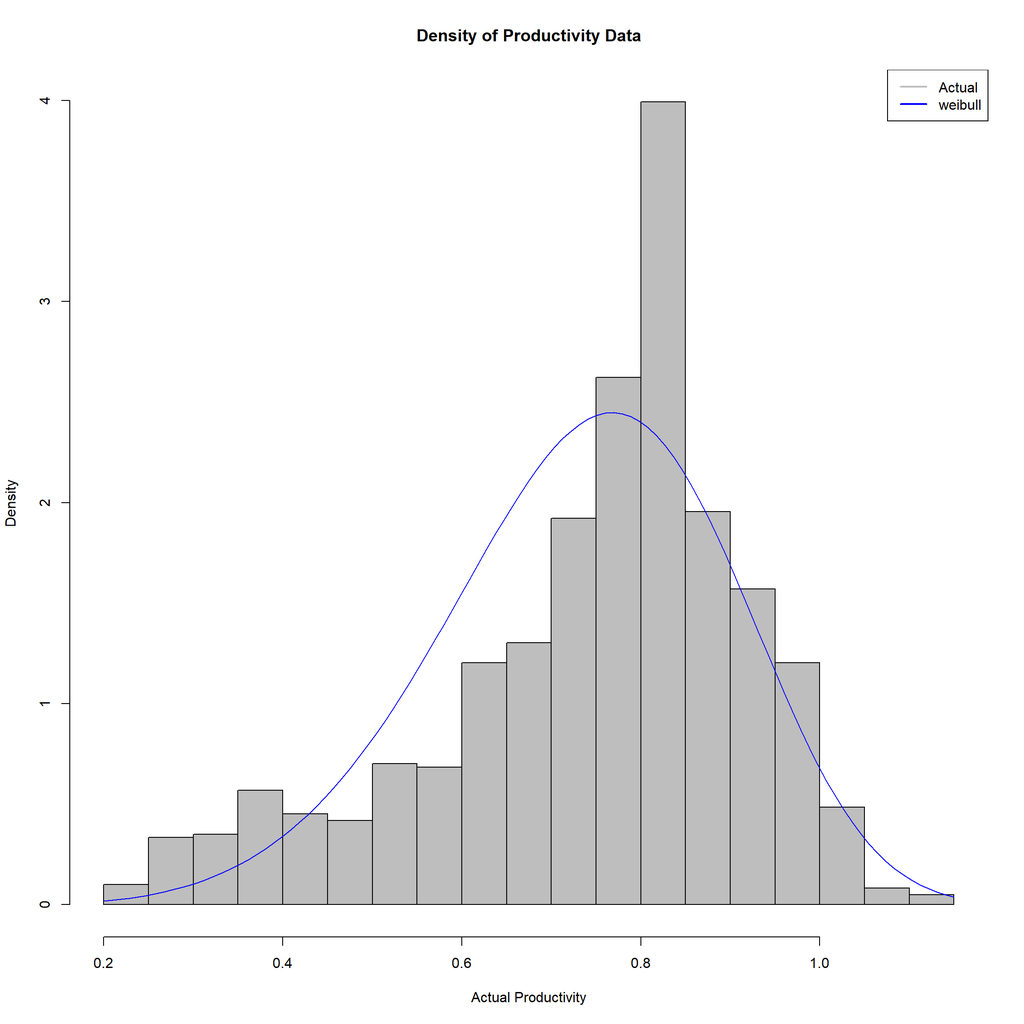

```r
# MLE 추정 결과 시각화

# weibull 분포 MLE 추정
x <- dat$actual_productivity
fit <- fitdist(x, 'weibull')

fit_shape <- fit$estimate[1]
fit_scale <- fit$estimate[2]

# 실제 데이터 히스토그램 및 MLE 모수로 가지는 분포 시각화
hist(x, col = 'grey', breaks = 20, prob = T, main = 'Density of Productivity Data', xlab = "Actual Productivity", ylab = "Density")
curve(dweibull(x, shape = fit_shape, scale = fit_scale), col = 'blue', add = T)
legend('topright', legend = c("Actual", 'weibull'), col = c('grey', 'blue'), lwd = 2)
```

#### 4. 주차 (quarter), 부서 (department), 요일 (day) 별로 목표하는 점수 (targeted_productivity), 실제 생산성 점수 (actual_productivity)에 차이가 없는지 그룹화를 수행하고 각 점수에 대해 기술통계량을 검토하시오. (10점)

- 기술통계량은 목표 점수, 실제 점수 모두 검토할 것
- 기술통계량 검토 결과를 해석하여 본인의 생각과 결론을 글로 작성할 것

```r
# 기술통계량 검토

# 목표 점수에 대한 데이터 그룹화 및 기술 통계량 출력
grp_target <- function(x=dat$targeted_productivity, grp) {
  dat_split <- split(x, grp)
  print(lapply(dat_split, summary))
}
# 생산성 점수에 대한 데이터 그룹화 및 기술 통계량 출력
grp_actual <- function(x=dat$actual_productivity, grp) {
  dat_split <- split(x, grp)
  print(lapply(dat_split, summary))
}
# 주차, 부서, 요일 각각의 기술 통계량 결과 도출
for(i in 1:3){
  cat(paste('##############', colnames(dat)[i],'##############\n'))
  cat('### 목표 점수 ###\n')
  grp_target(grp=dat[,i])
  cat('### 생산성 점수 ###\n')
  grp_actual(grp=dat[,i])
}
```

```
## ############## quarter ##############
## ### 목표 점수 ###
## $Quarter1
##    Min. 1st Qu.  Median    Mean 3rd Qu.    Max.
##  0.0700  0.7000  0.8000  0.7441  0.8000  0.8000
##
## $Quarter2
##    Min. 1st Qu.  Median    Mean 3rd Qu.    Max.
##  0.3500  0.7000  0.8000  0.7321  0.8000  0.8000
##
## $Quarter3
##    Min. 1st Qu.  Median    Mean 3rd Qu.    Max.
##  0.3500  0.7000  0.7500  0.7212  0.8000  0.8000
##
## $Quarter4
##    Min. 1st Qu.  Median    Mean 3rd Qu.    Max.
##  0.3500  0.7000  0.7500  0.7145  0.8000  0.8000
##
## $Quarter5
##    Min. 1st Qu.  Median    Mean 3rd Qu.    Max.
##  0.5000  0.6500  0.7500  0.7182  0.8000  0.8000
##
## ### 생산성 점수 ###
## $Quarter1
##    Min. 1st Qu.  Median    Mean 3rd Qu.    Max.
##  0.2610  0.7000  0.8000  0.7516  0.8501  1.0507
##
## $Quarter2
##    Min. 1st Qu.  Median    Mean 3rd Qu.    Max.
##  0.2337  0.6523  0.8000  0.7437  0.8505  1.1005
##
## $Quarter3
##    Min. 1st Qu.  Median    Mean 3rd Qu.    Max.
##  0.2358  0.6138  0.7254  0.7048  0.8004  1.1204
##
## $Quarter4
##    Min. 1st Qu.  Median    Mean 3rd Qu.    Max.
##  0.2594  0.6004  0.7504  0.7091  0.8144  1.0596
##
## $Quarter5
```

[output cut: 57 more lines]

```
## $Sunday
##    Min. 1st Qu.  Median    Mean 3rd Qu.    Max.
##  0.2358  0.6450  0.7507  0.7286  0.8504  1.1204
##
## $Thursday
##    Min. 1st Qu.  Median    Mean 3rd Qu.    Max.
##  0.2337  0.6104  0.7507  0.7226  0.8463  1.1005
##
## $Tuesday
##    Min. 1st Qu.  Median    Mean 3rd Qu.    Max.
##  0.2682  0.6811  0.7508  0.7427  0.8503  1.0336
##
## $Wednesday
##    Min. 1st Qu.  Median    Mean 3rd Qu.    Max.
##  0.2473  0.6566  0.7832  0.7305  0.8419  1.0503
```

#### -> 분기별로 생산성 점수를 비교했을때, 3/4 quarter에서 목표했던 수치를 달성하지 못했으며, 부서별로 데이터를 비교하였을때는 finishing 부서에서 높은 점수를 받았다. 요일별로 점수를 비교하였을때 요일별로 모두 기준을 달성한 것으로 보인다.

#### 5. 부서 (department) 별로 실제 생산성 점수 (actual_productivity)의 분포에 차이가 있다고 볼 수 있는지 검정하고자 한다. 신뢰수준 99% 하에서 모평균, 모분산 가설검정을 수행하시오. (10점)

- 가설검정을 수행할 때에는 5단계의 절차를 준용하여 코드 및 설명을 작성할 것
- 모평균 검정 시 모분산은 알려지지 않았으며, 부서별 생산성 점수의 모분산은 다르다고 가정

```r
## 모분산에 대해 알려져있지 않으므로 T분포로 진행.
## 1. 모평균 가설 설정
## H0 : 부서별로 실제 생산성 점수의 평균은 같다.
## H1 : 부서별로 실제 생산성 점수의 평균은 같지 않다.

## 2. 유의수준 설정 (a = 0.01)
alpha_t <- 0.01

## 3. 기각역 설정
## Z0 < -Z0.005 or Z0 > Z0.005

## 4. 검정 통계량 계산
dat_depart <- split(dat$actual_productivity, dat$department)
sweing <- dat_depart$sweing
finishing <- dat_depart$finishing
result_t <- t.test(sweing, finishing, conf.level = 0.99, var.equal = FALSE)
result_t
```

```
##
##  Welch Two Sample t-test
##
## data:  sweing and finishing
## t = -2.9314, df = 926.17, p-value = 0.003458
## alternative hypothesis: true difference in means is not equal to 0
## 99 percent confidence interval:
##  -0.058178928 -0.003696345
## sample estimates:
## mean of x mean of y
## 0.7220130 0.7529507
```

```r
## 5. 결론 도출
if(result_t$p.value < alpha_t) {
  print('검정 수행 결과 귀무 가설 기각한다.')
} else {
  print('검정 수행 결과 귀무 가설 채택한다.')
}
```

```
## [1] "검정 수행 결과 귀무 가설 기각한다."
```

```r
## 모분산 가설 검정
## 1. 가설 설정
## H0 : 부서별로 실제 생산성 점수의 편차는 같다.
## H1 : 부서별로 실제 생산성 점수의 편차는 같지 않다.

## 2. 유의수준 설정 (a = 0.01)
alpha_var <- 0.01

## 3. 기각역 설정
## Z0 < -Z0.005 or Z0 > Z0.005

## 4. 검정 통계량 계산
result_var <- var.test(sweing, finishing, conf.level = 0.99)
result_var
```

```
##
##  F test to compare two variances
##
## data:  sweing and finishing
## F = 0.6172, num df = 690, denom df = 505, p-value = 4.271e-09
## alternative hypothesis: true ratio of variances is not equal to 1
## 99 percent confidence interval:
##  0.4977228 0.7630273
## sample estimates:
## ratio of variances
##          0.6172043
```

```r
## 5. 결론 도출
if(result_var$p.value < alpha_var) {
  print('검정 수행 결과 귀무 가설 기각한다.')
} else {
  print('검정 수행 결과 귀무 가설 채택한다.')
}
```

```
## [1] "검정 수행 결과 귀무 가설 기각한다."
```

#### 6. 부서에 따라 목표 생산성 점수 (targeted_productivity) 대비 실제로 달성한 생산성 점수 (actual_productivity)를 초과하는 비율에 차이가 있는지 살펴보고자 한다. 부서 (department) 별로 목표량을 초과하여 생산이 이루어진 비율에 차이가 있는지 95% 신뢰수준 하에서 검정을 수행하고, 달성 비율 차이에 대한 신뢰구간을 산출하시오. (15점)

- 부서별 전체 데이터 중 목표 생산성 점수가 실제 생산성 점수를 초과하는 비율이 같은지 비교할 것

```r
## 1. 가설 검정
## H0 : 부서관계 없이 실제 생산성 점수가 목표 생산성 점수 초과하는 비율이 같다.
## H1 : 부서별로 실제 생산성 점수가 목표 생산성 점수 초과하는 비율이 다르다.

## 2. 유의수준 설정 (a = 0.05)
alpha_prop <- 0.05

## 3. 기각역 설정
## Z < -Z0.0025 or Z > Z0.0025

## 4. 검정 통계량 계산
dat_actual <- split(dat$actual_productivity, dat$department)
dat_target <- split(dat$targeted_productivity, dat$department)

ndat <- sapply(dat_actual, length)
np <- sapply(1:length(dat_actual), function(x) {
  actual <- dat_actual[[x]]
  target <- dat_target[[x]]
  return(sum(actual > target))
})

result_prop <- prop.test(np, ndat)
result_prop
```

```
##
##  2-sample test for equality of proportions with continuity correction
##
## data:  np out of ndat
## X-squared = 72.366, df = 1, p-value < 2.2e-16
## alternative hypothesis: two.sided
## 95 percent confidence interval:
##  -0.2768567 -0.1705673
## sample estimates:
##    prop 1    prop 2
## 0.5968379 0.8205499
```

```r
## 5. 결론 도출
if(result_prop$p.value < alpha_prop) {
  print('검정 수행 결과 귀무 가설 기각한다.')
  print('즉, 부서별 전체 데이터 중 목표 생산성 점수가 실제 생산성 점수를 초과하는 비율이 다르다')
} else {
  print('검정 수행 결과 귀무 가설 채택한다.')
}
```

```
## [1] "검정 수행 결과 귀무 가설 기각한다."
## [1] "즉, 부서별 전체 데이터 중 목표 생산성 점수가 실제 생산성 점수를 초과하는 비율이 다르다"
```

```r
## 부서별 달성 비율 차이에 대한 신뢰 구간 산출
##result_prop$conf.int[1]
##result_prop$conf.int[2]
cal_ci <- function(np, ndat) {
  p1 <- np[1] / ndat[1]
  p2 <- np[2] / ndat[2]

  se <- sqrt((p1*(1-p1))/ndat[1] + (p2*(1-p2))/ndat[2])
  ci <- (p1-p2+c(-1,1)*1.96*se)

  print(paste('달성 비율 차이에 대한 95% 신뢰구간은 ', ci[1], ', ', ci[2], '입니다.'))
}

cal_ci(np, ndat)
```

```
## [1] "달성 비율 차이에 대한 95% 신뢰구간은  -0.275145910725513 ,  -0.172278055228623 입니다."
```

#### 7. 생산 공정에 투입되는 인원 (team)이 요일 (day)에 관계없이 동일한지 검정하고자 한다. 신뢰수준 95%에서 가설검정을 수행하시오. (15점)

- 요일별로 평균적인 투입 인원을 산출할 것
- 실제 투입 인원이 요일에 관계없이 동일한 경우와 비교하여 가설검정을 수행할 것

```r
## 1. 가설 검정
## H0 : 생산 공정에 투입되는 인원이 요일에 관계없이 동일하다.
## H1 : 생산 공정에 투입되는 인원이 요일별로 다르다.

## 2. 유의수준 설정 (a = 0.05)
alpha_chi <- 0.05

## 3. 기각역 설정
## Z < z0.05

## 4. 검정 통계량 계산
## 요일별 평균적인 투입 인원 산출
team_mean <- tapply(dat$team, dat$day, mean)
## 요일, 인원 두 변수에 대한 이차분할표 생성
team_table <- table(dat$team, dat$day)

result_chi <- chisq.test(team_table)
result_chi
```

```
##
##  Pearson's Chi-squared test
##
## data:  team_table
## X-squared = 4.4457, df = 55, p-value = 1
```

```r
#dat_table <- function(x){
#  ob <- table(x)
#  ex <- rep(mean(ob), length(ob))
#  chisq.test(rbind(ob,ex))
#}
#chisq_test <- print(dat_table(dat$day))

## 5. 결론 도출
if(result_chi$p.value < alpha_chi) {
  print('검정 수행 결과 귀무 가설 기각한다.')
} else {
  print('검정 수행 결과 귀무 가설 채택한다.')
}
```

```
## [1] "검정 수행 결과 귀무 가설 채택한다."
```

#### 8. 초과근무 시간 (over_time)과 성과급 (incentive)이 연관성이 있는지 가설검정을 통하여 확인하고자 한다. 신뢰수준 90%에서 가설검정을 수행하고, 이에 대한 결론을 도출하시오. (15점)

- 이상치를 배제하기 위하여 인센티브는 80, 초과근무는 8000 미만인 대상만 고려할 것
- 연속형 변수의 경우, 이산화를 진행하여 변수를 처리해주어야 함
- 검정을 위한 테이블은 5행 5열로 구성할 것

```r
# 이상치 배제를 위한 데이터 전처리 진행
dat <- dat[!(dat$incentive > 80 ), ]
dat <- dat[!(dat$over_time > 8000 ), ]
# 연속형 변수의 경우, 이산화를 진행하여 변수를 처리해주어야 함
# 검정을 위한 테이블은 5행 5열로 구성할 것
grp_incen <- function(x){
  cut(x,breaks=c(0, 16, 32, 48, 64, 80), include.lowest=T)
}
grp_over <- function(x){
  cut(x,breaks=c(0, 1600, 3200, 4800, 6400, 8000), include.lowest=T)
}
dat$incentive <- grp_incen(dat$incentive)
dat$over_time <- grp_over(dat$over_time)

## 1. 가설 검정
## H0 : 초과근무 시간 (over_time)과 성과급 (incentive) 변수 사이에는 연관성이 없다.
## H1 : 초과근무 시간 (over_time)과 성과급 (incentive) 변수 사이에는 연관성이 있다.

## 2. 유의수준 설정 (a = 0.1)
alpha_chi2 <- 0.1

## 3. 기각역 설정
## Z < Z0.1

## 4. 검정 통계량 계산
options(scipen=9999)
chi_table <- table(dat$over_time, dat$incentive)
chi_table
```

```
##
##                     [0,16] (16,32] (32,48] (48,64] (64,80]
##   [0,1.6e+03]          324       6       8       9       2
##   (1.6e+03,3.2e+03]    113       9       5       7       0
##   (3.2e+03,4.8e+03]     57      21      30      50       2
##   (4.8e+03,6.4e+03]     33      14      28      30       3
##   (6.4e+03,8e+03]       60      33      42      60      10
```

```r
result_chi2 <- chisq.test(chi_table)
result_chi2
```

```
##
##  Pearson's Chi-squared test
##
## data:  chi_table
## X-squared = 366.35, df = 16, p-value < 0.00000000000000022
```

```r
## 5. 결론 도출
if(result_chi2$p.value < alpha_chi2) {
  print('검정 수행 결과 귀무 가설 기각한다.')
} else {
  print('검정 수행 결과 귀무 가설 채택한다.')
}
```

```
## [1] "검정 수행 결과 귀무 가설 기각한다."
```